# IBM HR Analytics

# About

This project is part of the first group homework of [Applied Statistics with R](https://mam2021.netlify.app/) taught by Professor Kostis Christodoulou at **London Business School**.

My collaborators are Alessandro Angeletti, Nitya Chopra, Johanna Jeffery, and Christopher Lewis. (Hail Group 13!)

# Let’s do this

We first get the HR data from local.

```r
# loading and viewing the HR dataset
hr_dataset <- read_csv(here::here("data",
                                  "datasets_1067_1925_WA_Fn-UseC_-HR-Employee-Attrition.csv"))
```

Then we clean the dataset by assigning numerical data to more descriptive data.

```r
hr_cleaned <- hr_dataset %>%
  clean_names() %>%
  mutate(
    education = case_when(
      education == 1 ~ "Below College",
      education == 2 ~ "College",
      education == 3 ~ "Bachelor",
      education == 4 ~ "Master",
      education == 5 ~ "Doctor"
    ),
    environment_satisfaction = case_when(
      environment_satisfaction == 1 ~ "Low",
      environment_satisfaction == 2 ~ "Medium",
      environment_satisfaction == 3 ~ "High",
      environment_satisfaction == 4 ~ "Very High"
    ),
    job_satisfaction = case_when(
      job_satisfaction == 1 ~ "Low",
      job_satisfaction == 2 ~ "Medium",
      job_satisfaction == 3 ~ "High",
      job_satisfaction == 4 ~ "Very High"
    ),
    performance_rating = case_when(
      performance_rating == 1 ~ "Low",
      performance_rating == 2 ~ "Good",
      performance_rating == 3 ~ "Excellent",
      performance_rating == 4 ~ "Outstanding"
    ),
    work_life_balance = case_when(
      work_life_balance == 1 ~ "Bad",
      work_life_balance == 2 ~ "Good",
      work_life_balance == 3 ~ "Better",
      work_life_balance == 4 ~ "Best"
    )
  ) %>%
  select(age, attrition, daily_rate, department,
         distance_from_home, education,
         gender, job_role,environment_satisfaction,
         job_satisfaction, marital_status,
         monthly_income, num_companies_worked, percent_salary_hike,
         performance_rating, total_working_years,
         work_life_balance, years_at_company,
         years_since_last_promotion)
# print
hr_cleaned
```

```
## # A tibble: 1,470 x 19
##      age attrition daily_rate department distance_from_h… education gender
##    <dbl> <chr>          <dbl> <chr>                 <dbl> <chr>     <chr>
##  1    41 Yes             1102 Sales                     1 College   Female
##  2    49 No               279 Research …                8 Below Co… Male
##  3    37 Yes             1373 Research …                2 College   Male
##  4    33 No              1392 Research …                3 Master    Female
##  5    27 No               591 Research …                2 Below Co… Male
##  6    32 No              1005 Research …                2 College   Male
##  7    59 No              1324 Research …                3 Bachelor  Female
##  8    30 No              1358 Research …               24 Below Co… Male
##  9    38 No               216 Research …               23 Bachelor  Male
## 10    36 No              1299 Research …               27 Bachelor  Male
## # … with 1,460 more rows, and 12 more variables: job_role <chr>,
## #   environment_satisfaction <chr>, job_satisfaction <chr>,
## #   marital_status <chr>, monthly_income <dbl>, num_companies_worked <dbl>,
## #   percent_salary_hike <dbl>, performance_rating <chr>,
## #   total_working_years <dbl>, work_life_balance <chr>, years_at_company <dbl>,
## #   years_since_last_promotion <dbl>
```

Below are some calculations to better understand the hr_cleaned dataset.

```r
# calculate attrition rate
attrition_rate <- hr_cleaned %>%
  count(attrition)

attrition_rate
```

```
## # A tibble: 2 x 2
##   attrition     n
##   <chr>     <int>
## 1 No         1233
## 2 Yes         237
```

Out of all the employees, 237 employees left and 1233 employees stayed. So the attrition rate is roughly 16.12%

Next, we try to understand the causal factors behind such an attrition rate by examining the different variables that could’ve influenced it.

```r
# view summary of 'age', 'years_at_company',
#'monthly_income' and 'years_since_last_promotion'.
summary(hr_cleaned$age)
```

```
##    Min. 1st Qu.  Median    Mean 3rd Qu.    Max.
##    18.0    30.0    36.0    36.9    43.0    60.0
```

```r
summary(hr_cleaned$years_at_company)
```

```
##    Min. 1st Qu.  Median    Mean 3rd Qu.    Max.
##       0       3       5       7       9      40
```

```r
summary(hr_cleaned$monthly_income)
```

```
##    Min. 1st Qu.  Median    Mean 3rd Qu.    Max.
##    1009    2911    4919    6503    8379   19999
```

```r
summary(hr_cleaned$years_since_last_promotion)
```

```
##    Min. 1st Qu.  Median    Mean 3rd Qu.    Max.
##    0.00    0.00    1.00    2.19    3.00   15.00
```

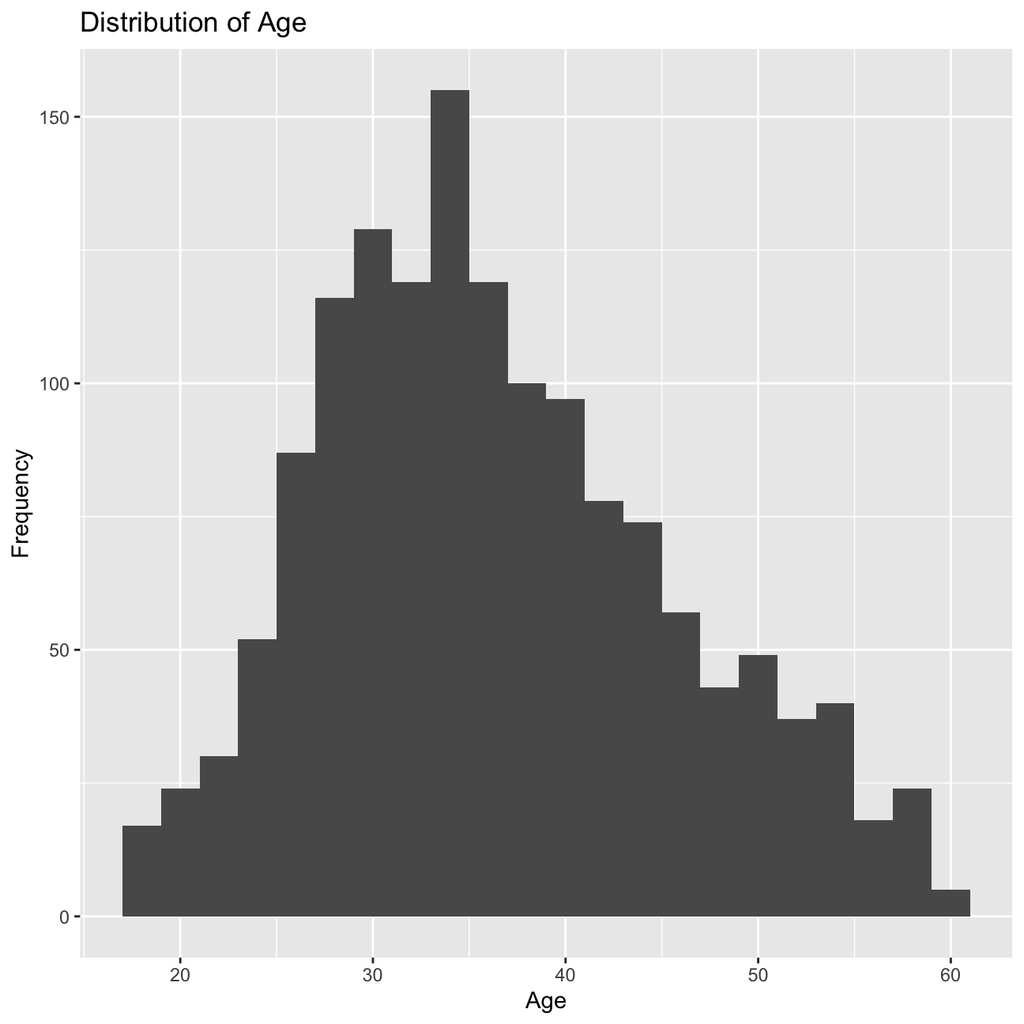

```r
# create a histogram to see the age distribution of all employees
hr_plot_age <- hr_cleaned %>%
  ggplot(data = hr_cleaned,
         mapping = aes(
           x = age,
           fill = age)) +
  geom_histogram(binwidth = 2) +
  labs(title = "Distribution of Age",
       x = "Age",
       y = "Frequency") +
  theme(legend.position = "none") +
  NULL

hr_plot_age
```

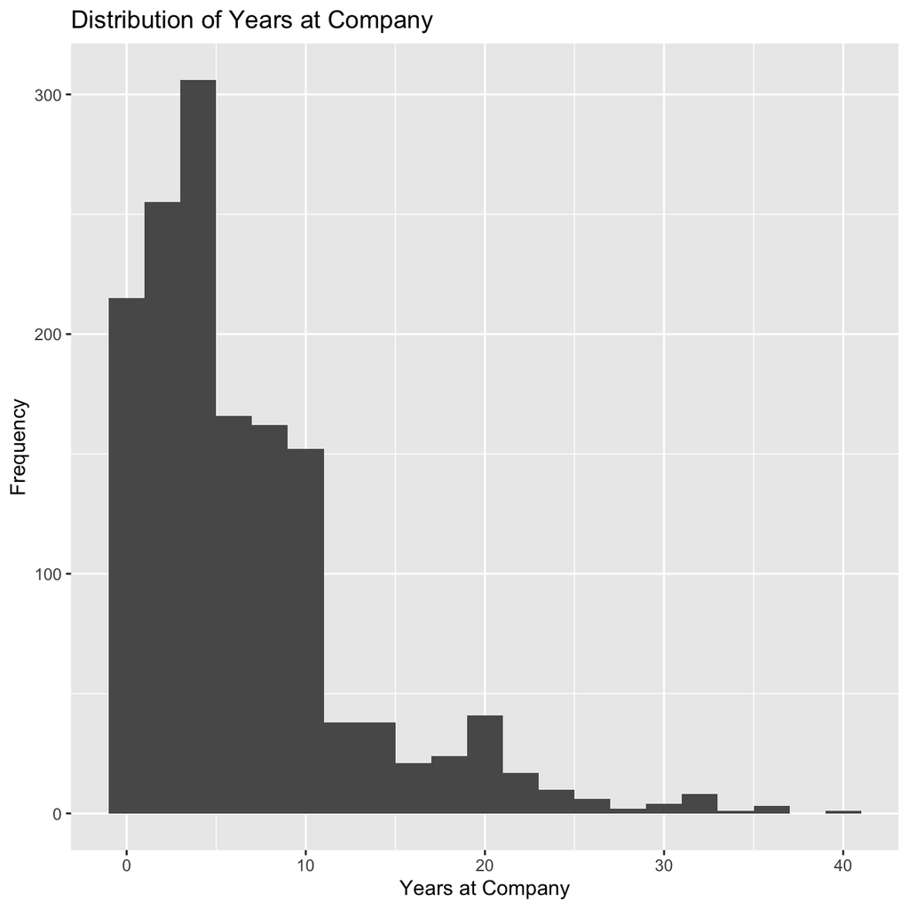

```r
# create a histogram to see the distribution of employment tenure -
# years for which employees have worked at IBM
hr_plot_years <- hr_cleaned %>%
  ggplot(data = hr_cleaned,
         mapping = aes(
           x = years_at_company,
           fill = years_at_company)) +
  geom_histogram(binwidth = 2) +
  labs(title = "Distribution of Years at Company",
       x = "Years at Company",
       y = "Frequency") +
  theme(legend.position = "none") +
  NULL

hr_plot_years
```

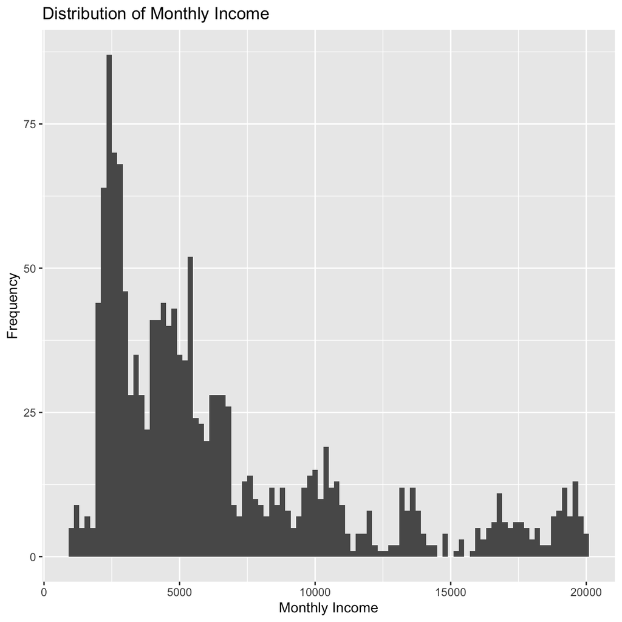

```r
# create a histogram to see the distribution
# of monthly income for all employees
hr_plot_income <- hr_cleaned %>%
  ggplot(data = hr_cleaned,
         mapping = aes(
           x = monthly_income,
           fill = monthly_income)) +
  geom_histogram(binwidth = 200) +
  labs(title = "Distribution of Monthly Income",
       x = "Monthly Income",
       y = "Frequency") +
  theme(legend.position = "none") +
  NULL

hr_plot_income
```

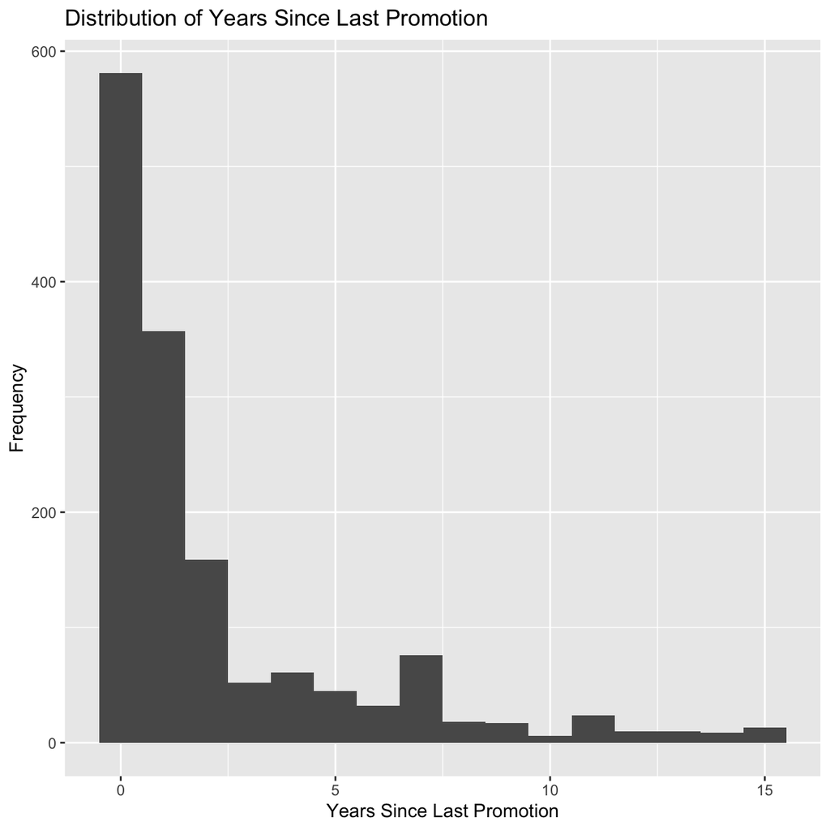

```r
# create a histogram to see the distribution of
#how many years have passed since employees were last promoted
hr_plot_last_promotion <- hr_cleaned %>%
  ggplot(data = hr_cleaned,
         mapping = aes(
           x = years_since_last_promotion,
           fill = years_since_last_promotion)) +
  geom_histogram(binwidth = 1) +
  labs(title = "Distribution of Years Since Last Promotion",
       x = "Years Since Last Promotion",
       y = "Frequency") +
  theme(legend.position = "none") +
  NULL

hr_plot_last_promotion
```

To make things easier, we also order the descriptive variables in ‘job_satisfaction’ in an appropriate manner and calculate percentage for each of them.

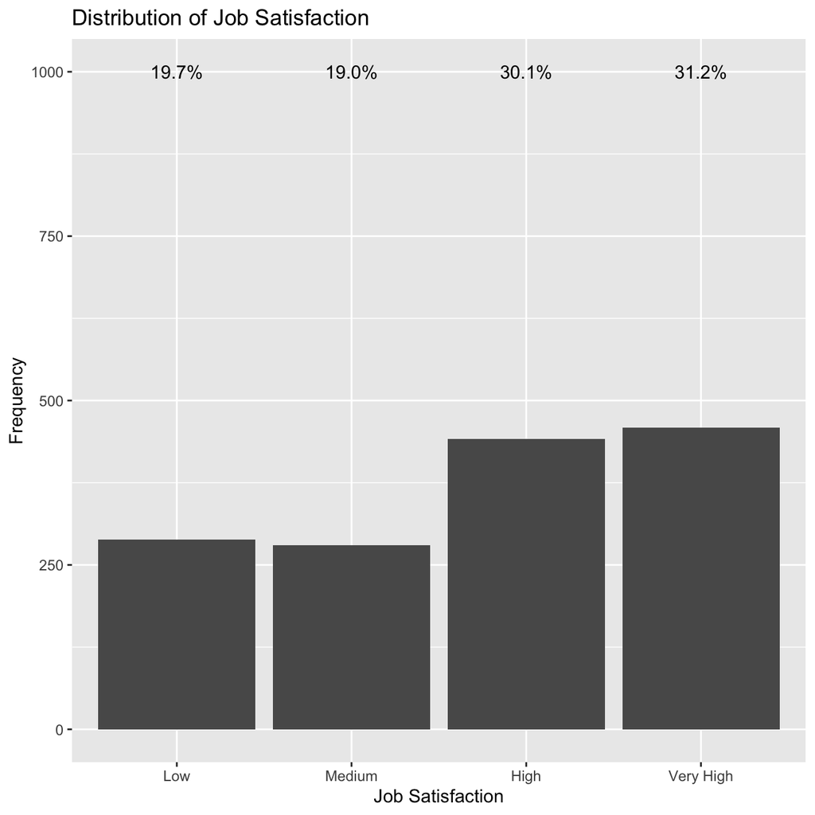

```r
hr_cleaned$job_satisfaction <- factor(hr_cleaned$job_satisfaction,
                                      levels = c("Low", "Medium", "High", "Very High"))

job_satisfaction_percent <- hr_cleaned %>%
  count(job_satisfaction) %>%
  mutate(n/sum(n)*100)

# plot a histogram for job satisfaction
hr_plot_satisfaction <- hr_cleaned %>%
  ggplot(data = hr_cleaned,
         mapping = aes(x = job_satisfaction)) +
  geom_bar(binwidth = 1) +
  labs(title = "Distribution of Job Satisfaction",
       x = "Job Satisfaction",
       y = "Frequency") +
  theme(legend.position = "none") +
  annotate("text",
           x = 1:4,
           y = 1000:1000:1000:1000,
           label = c("19.7%", "19.0%", "30.1%", "31.2%")) +
  NULL

hr_plot_satisfaction
```

In addition, we also order the descriptive variables in ‘work_life_balance’ appropriately

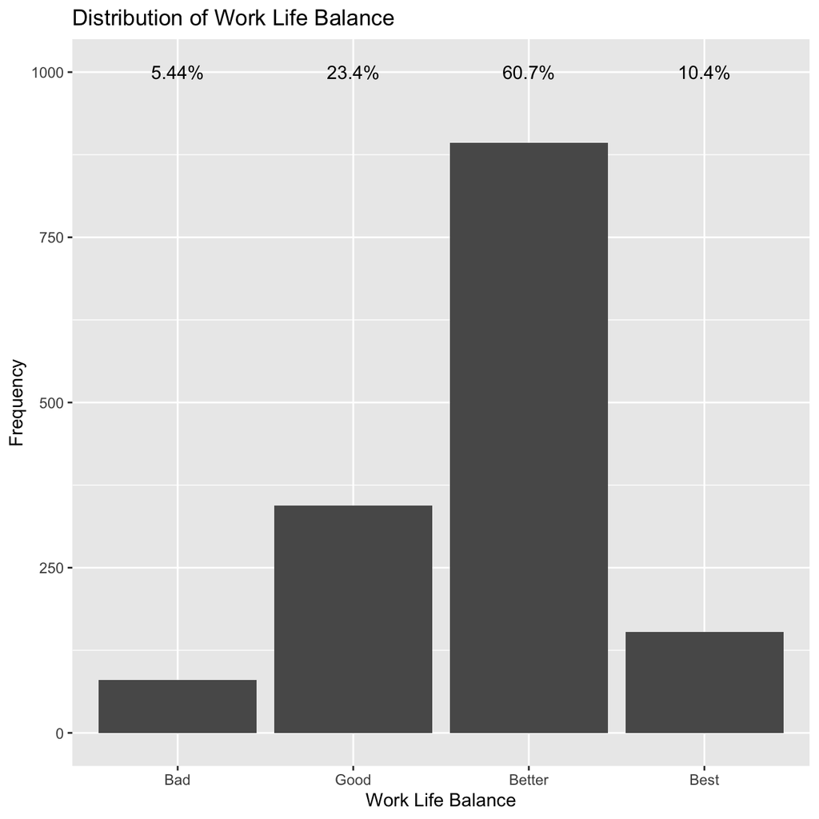

```r
hr_cleaned$work_life_balance <- factor(hr_cleaned$work_life_balance,
                                       levels  = c("Bad", "Good", "Better", "Best"))

work_life_percent <- hr_cleaned %>%
  count(work_life_balance) %>%
  mutate(n/sum(n)*100)

# plot a histogram for distribution of work life balance across employees
hr_plot_worklife <- hr_cleaned %>%
  ggplot(data = hr_cleaned,
         mapping = aes(x = work_life_balance)) +
  geom_bar(binwidth = 1) +
  labs(title = "Distribution of Work Life Balance",
       x = "Work Life Balance",
       y = "Frequency") +
  theme(legend.position = "none") +
  annotate("text",
           x = 1:4,
           y=1000:1000:1000:1000,
           label = c("5.44%", "23.4%", "60.7%", "10.4%")) +
  NULL

hr_plot_worklife
```

Next, we examine the relationship between monthly income and other variables such as level of education, gender, job role, etc.

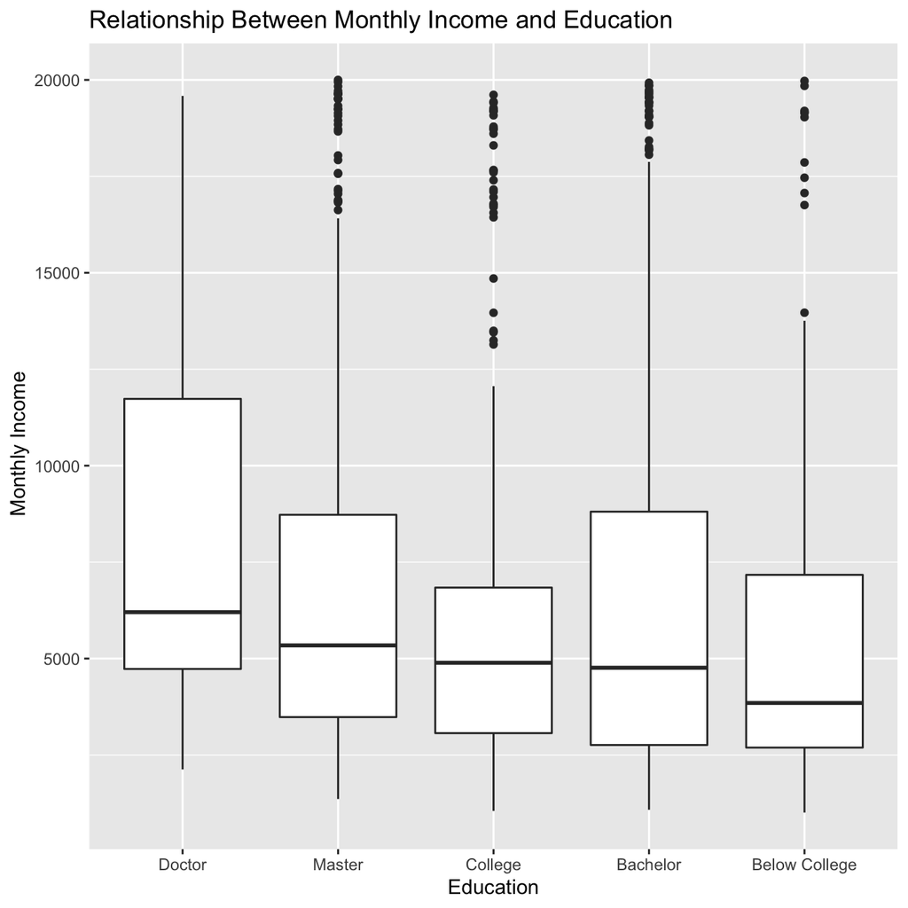

```r
# plot for monthly income and education
ggplot(data = hr_cleaned,
       mapping = aes(
         x = reorder(education, -monthly_income, FUN = median),
         y = monthly_income)) +
  geom_boxplot() +
  labs(title = "Relationship Between Monthly Income and Education",
       x = "Education",
       y = " Monthly Income") +
  NULL
```

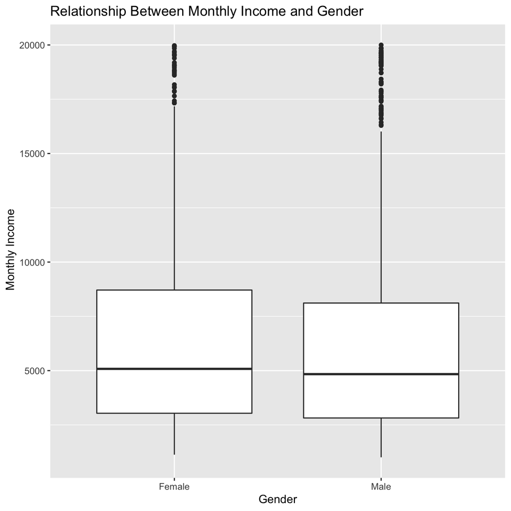

```r
# plot for monthly income and gender
ggplot(data = hr_cleaned,
       mapping = aes(
         x = gender,
         y = monthly_income)) +
  geom_boxplot() +
  labs(title = "Relationship Between Monthly Income and Gender",
       x = "Gender",
       y = " Monthly Income") +
  NULL
```

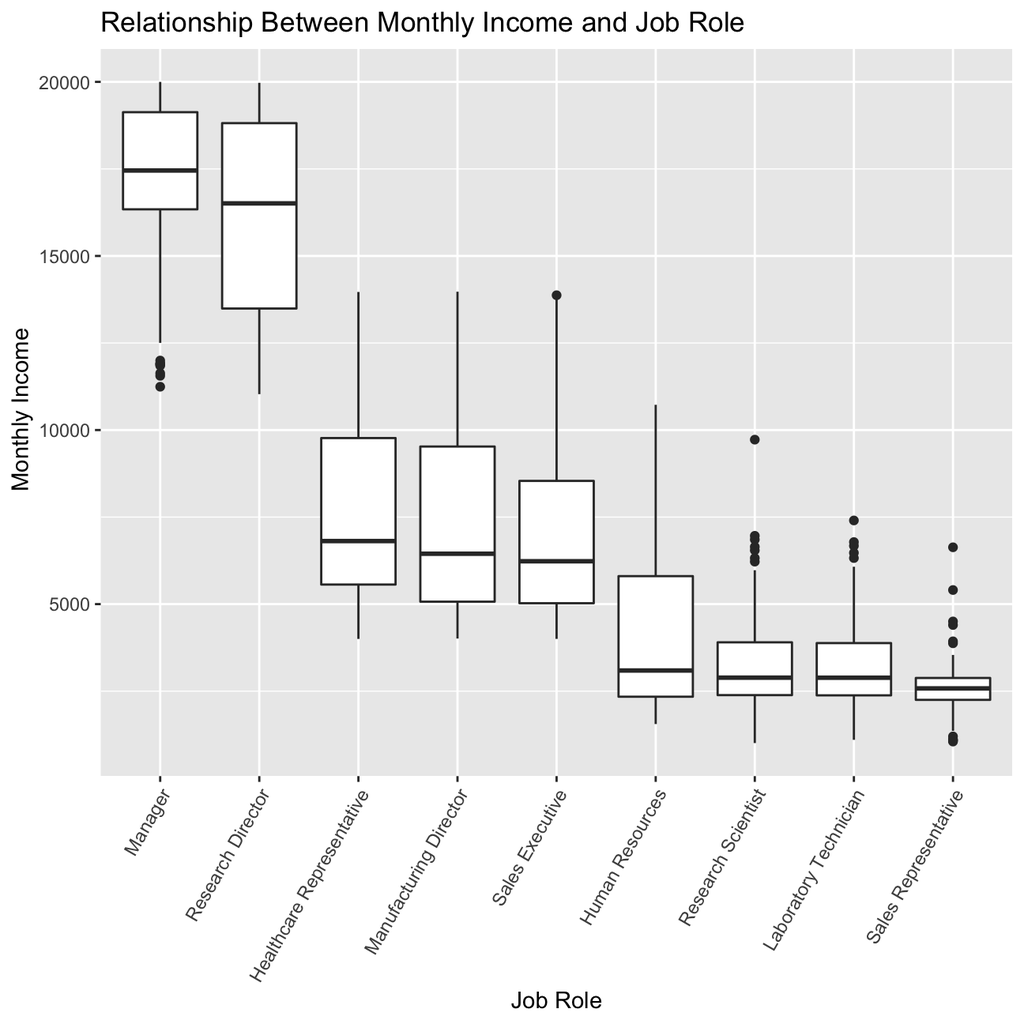

```r
# plot for monthly income and job role
ggplot(data = hr_cleaned,
       mapping = aes(
         x = reorder(job_role, -monthly_income),
         y = monthly_income)) +
  geom_boxplot() +
  labs(title = "Relationship Between Monthly Income and Job Role",
       x = "Job Role",
       y = " Monthly Income") +
  theme(axis.text.x = element_text(angle=60, hjust=1)) +
  NULL
```

```r
# calculate median
median_monthly_income <- hr_cleaned %>%
  group_by(education) %>%
  mutate(median(monthly_income))

median_monthly_income
```

```
## # A tibble: 1,470 x 20
## # Groups:   education [5]
##      age attrition daily_rate department distance_from_h… education gender
##    <dbl> <chr>          <dbl> <chr>                 <dbl> <chr>     <chr>
##  1    41 Yes             1102 Sales                     1 College   Female
##  2    49 No               279 Research …                8 Below Co… Male
##  3    37 Yes             1373 Research …                2 College   Male
##  4    33 No              1392 Research …                3 Master    Female
##  5    27 No               591 Research …                2 Below Co… Male
##  6    32 No              1005 Research …                2 College   Male
##  7    59 No              1324 Research …                3 Bachelor  Female
##  8    30 No              1358 Research …               24 Below Co… Male
##  9    38 No               216 Research …               23 Bachelor  Male
## 10    36 No              1299 Research …               27 Bachelor  Male
## # … with 1,460 more rows, and 13 more variables: job_role <chr>,
## #   environment_satisfaction <chr>, job_satisfaction <fct>,
## #   marital_status <chr>, monthly_income <dbl>, num_companies_worked <dbl>,
## #   percent_salary_hike <dbl>, performance_rating <chr>,
## #   total_working_years <dbl>, work_life_balance <fct>, years_at_company <dbl>,
## #   years_since_last_promotion <dbl>, `median(monthly_income)` <dbl>
```

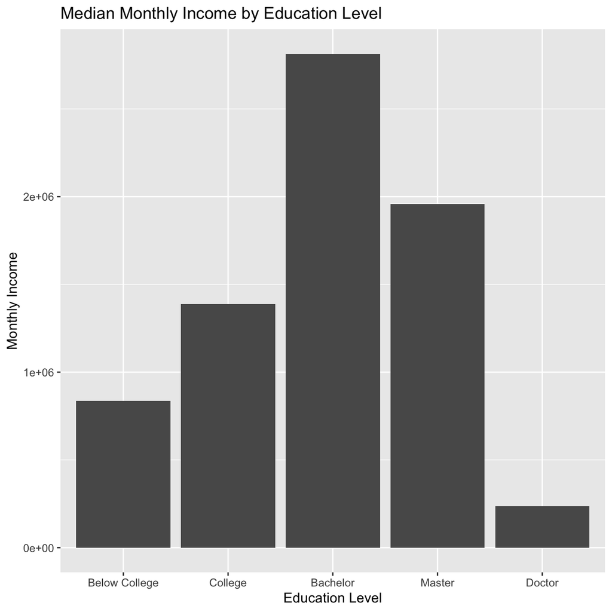

```r
# plot bar chart for median monthly income
ggplot(data = hr_cleaned,
       mapping = aes(
         x = reorder(education, monthly_income),
         y = median(monthly_income))) +
  geom_col() +
  labs(title = "Median Monthly Income by Education Level",
       x = "Education Level",
       y = "Monthly Income") +
  NULL
```

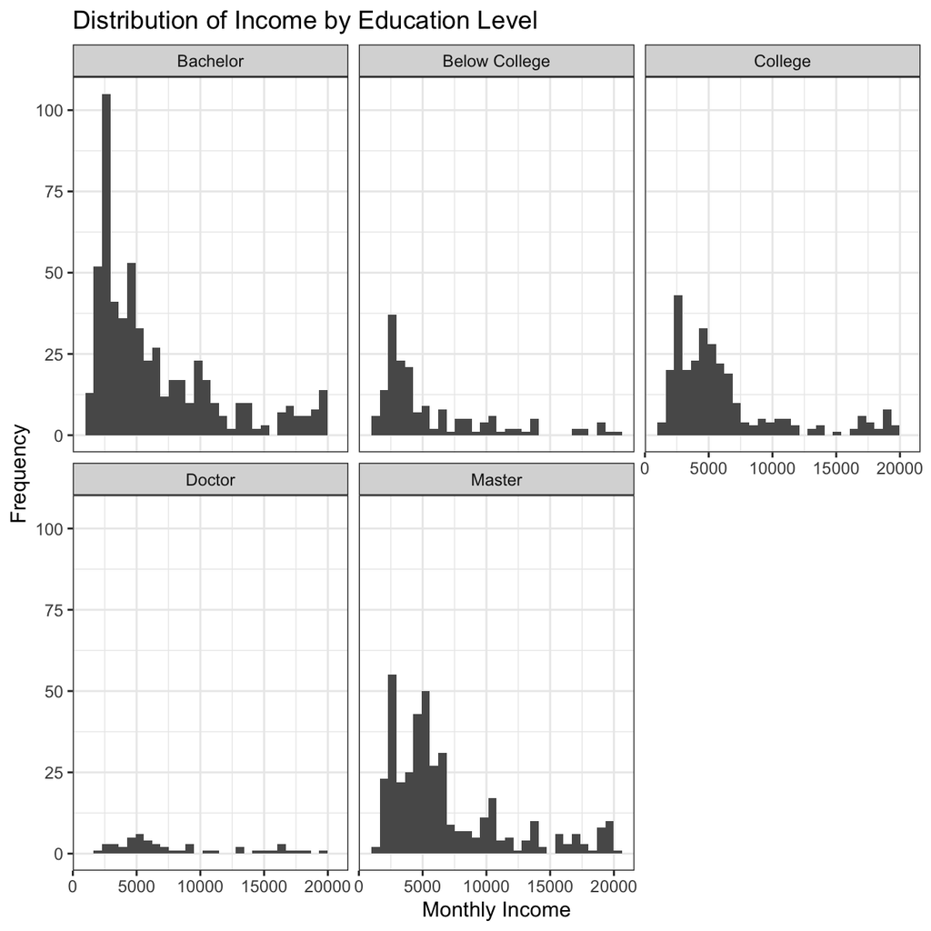

```r
# The distribution of income is created and faceted by education level
ggplot(data = hr_cleaned,
       mapping = aes(x = monthly_income)) +
  geom_histogram() +
  facet_wrap(~education) +
  labs(title = "Distribution of Income by Education Level",
       x = "Monthly Income",
       y = "Frequency") +
  theme_bw() +
  NULL
```

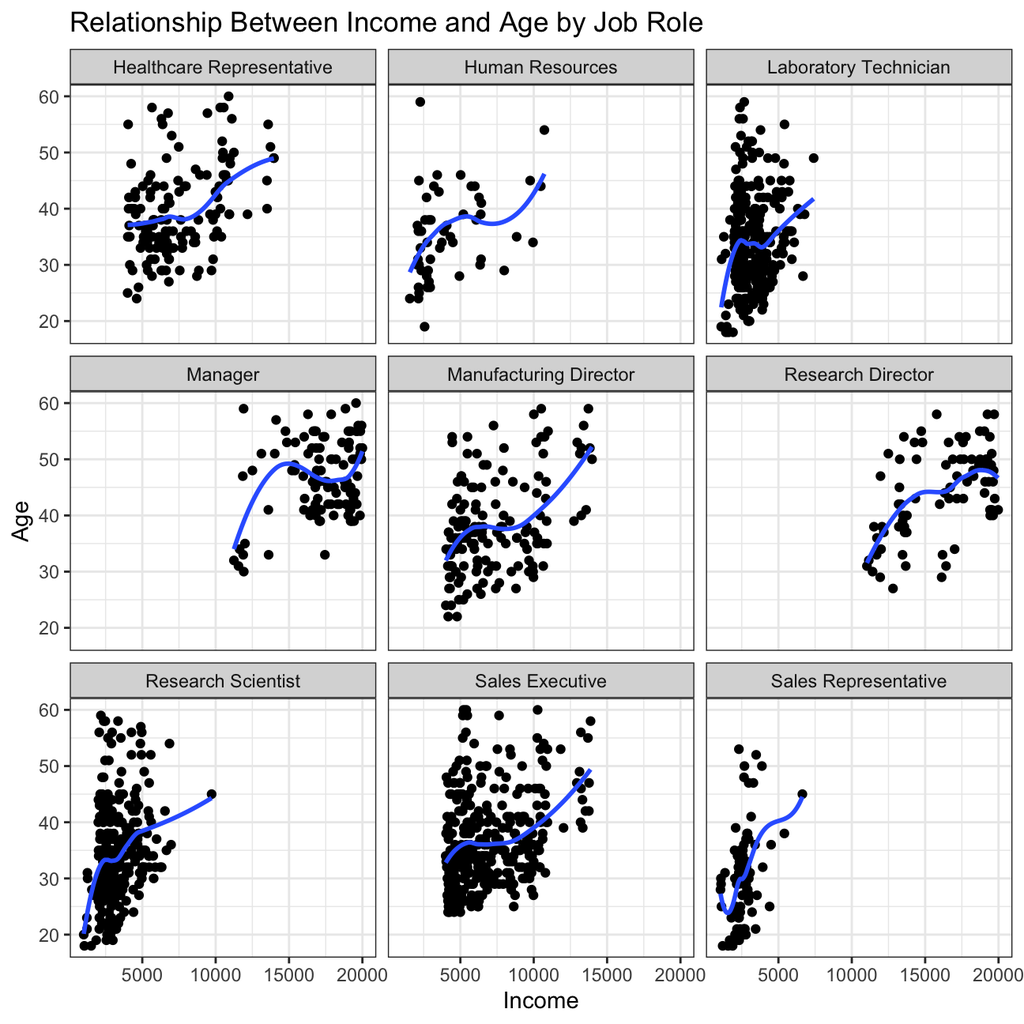

```r
# The relationship between monthly income and age is identified and faceted by profession
ggplot(data = hr_cleaned,
       mapping = aes(
         x = monthly_income,
         y = age)) +
  geom_point() +
  facet_wrap(~job_role) +
  labs(title = "Relationship Between Income and Age by Job Role",
       x = "Income",
       y = "Age") +
  theme_bw() +
  geom_smooth(se = FALSE) +
NULL
```

The above plots highlight relationships between different variables in the dataset hr_cleaned.

As seen in the dataset, the data provided from IBM shows an attrition rate of around 16%, indicating 84% of employees remained with the firm.

The variables of ‘age’, ‘years at company’, ‘monthly income’ and ‘years since last promotion’ are further analyzed to understand their distribution. The summary statistics alone can give us a good indication on if the distribution is not normal. However, it is hard to assert if the distribution is normal only from this data. In this case, by looking at the summary data the distributions of years at company / income / years since last promotion were not normal. However, to understand if age was a normal distribution, a histogram plot was required.

# Takeaway

This analytic project mainly exercises the use of:

- Function: `case_when`, `summary`.